# Introduction to ERGMs

Have you ever wondered if the friend of your friend is your friend? Or if the people you consider to be your friends feel the same about you? Or if age is related to whether you seek advice from others? All these (and many others certainly more creative) questions can be answered using Exponential-Family Random Graph Models.

# 1 Introduction

Exponential-Family Random Graph Models, known as ERGMs, ERG Models, or $p^*$ models (Holland and Leinhardt (1981), Frank and Strauss (1986), Wasserman and Pattison (1996), Snijders et al. (2006), Robins et al. (2007), and many others) are a large family of statistical distributions for random graphs. In ERGMs, the focus is on the processes that give origin to the network rather than the individual ties.[^1]

The most common representation of ERGMs is the following:

$$P_{\mathcal{Y}, \bm{\theta}}(\bm{Y}=\bm{y}) = \exp\left(\bm{\theta}^{\mathbf{t}} s(y)\right)\kappa(\bm{\theta})^{-1}$$

where $\bm{Y}$ is a random graph, $\bm{y}\in \mathcal{Y}$ is a particular realization of $Y$, $\bm{\theta}$ is a vector of parameters, $s(\bm{y})$ is a vector of sufficient statistics, and $\kappa(\bm{\theta})$ is a normalizing constant. The normalizing constant is defined as:

$$\kappa(\bm{\theta}) = \sum_{\bm{y} \in \mathcal{Y}} \exp\left(\bm{\theta}^{\mathbf{t}} s(\bm{y})\right)$$

In more simple terms, ERG models resemble Logistic regressions. The term $\bm{\theta}^{\mathbf{t}} s(\bm{y})$ is the sum of the product between the parameters and the statistics (like you would see in a Logistic regression,) and its key component is the composition of the vector of sufficient statistics, $s(\bm{y})$. The latter is what defines the model.

The vector of sufficient statistics dictates the data-generating process of the network. Like the mean and variance characterize the normal distribution, sufficient statistics (and corresponding parameters) characterize the ERG distribution. Figure 1 shows some examples of sufficient statistics with their corresponding parametrizations.

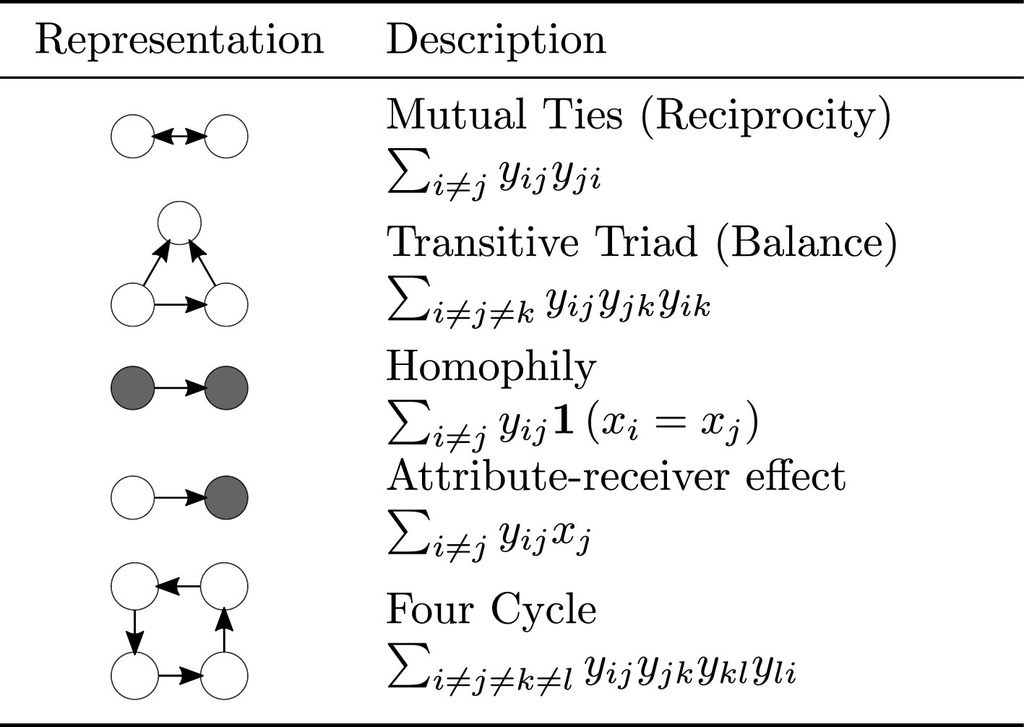

Figure 1: Example ERGM terms from Vega Yon, Slaughter, and Haye (2021)

The `ergm` package has many terms we can use to fit these models. You can explore the available terms in the manual `ergm.terms` in the `ergm` package. Take a moment to explore the manual and see the different terms available.

# 2 Dyadic independence (p1)

The simplest ERG model we can fit is a Bernoulli (Erdos-Renyi) model. Here, the only statistic is the edgecount. Now, if we can write the function computing sufficient statistics as a sum over all edges, *i.e.*, $s(\bm{y}) = \sum_{ij}s'(y_{ij})$, the model reduces to a Logistic regression.

```r
library(ergm)

# Simulating a Bernoulli network
Y <- matrix(rbinom(100^2, 1, 0.1), 100, 100)
diag(Y) <- NA

cbind(
  logit = glm(as.vector(Y) ~ 1, family = binomial) |> coef(),
  ergm  = ergm(Y ~ edges) |> coef(),
  avg   = mean(Y, na.rm = TRUE) |> qlogis()
)
##                 logit      ergm       avg
## (Intercept) -2.199471 -2.199471 -2.199471
```

When we see this, we say that dyads are independent of each other; this is also called *p1* models (Holland and Leinhardt 1981). As a second example, imagine that we are interested in assessing whether gender homophily (the tendency between individuals of the same gender to connect) is present in a network. ERG models are the right tool for this task. Moreover, if we assume that gender homophily is the only mechanism that governs the network, the problem reduces to a Logistic regression:

$$P_{\mathcal{Y}, \bm{\theta}}(y_{ij} = 1) = \text{Logit}^{-1}\left(\theta_{edges} + \theta_{homophily}\mathbb{1}\left(X_i = X_j\right)\right)$$

where $\mathbb{1}\left(\cdot\right)$ is the indicator function, and $X_i$ equals one if the $ith$ individual is female, and zero otherwise. To see this, let’s simulate some data. We will use the `simulate_formula` function in the `ergm` package. All we need is a network, a model, and some arbitrary coefficients. We start with an indicator vector for gender (1: female, male otherwise):

```r
# Simulating data
set.seed(7731)
X <- rbinom(100, 1, 0.5)
head(X)
```

```
[1] 0 1 0 0 1 0
```

Next, we use the functions from the `ergm` and `network` packages to simulate a network with homophily:

```r
# Simulating the network with homophily
library(ergm)

# A network with 100 vertices
Y <- network(100)

# Adding the vertex attribute with the %v% operator
Y %v% "X" <- X

# Simulating the network
Y <- ergm::simulate_formula(
  # The model
  Y ~ edges + nodematch("X"),
  # The coefficients
  coef = c(-3, 2)
  )
```

In this case, the network tends to be sparse (negative edges coefficient) and present homophilic ties (positive nodematch coefficient). Using the `sna` package (also from the `statnet` suite), we can plot the network:

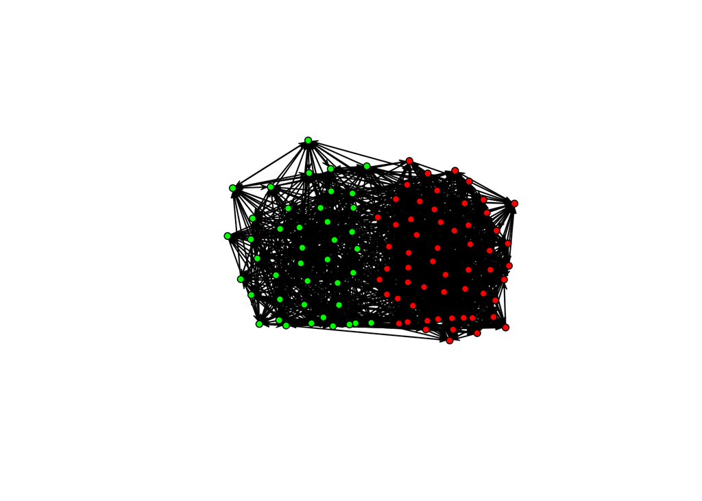

```r
library(sna)
gplot(Y, vertex.col = c("green", "red")[Y %v% "X" + 1])
```

Using the ERGM package, we can fit the model using code very similar to the one used to simulate the network:

```r
fit_homophily <- ergm(Y ~ edges + nodematch("X"))
```

We will check the results later and compare them against the following: the Logit model. The following code chunk implements the logistic regression model for this particular model. This example only proves that ERGMs are a generalization of Logistic regression.

**Only to learn!**

This example was created only for learning purposes. In practice, you should **always** use the `ergm` package or `PNet` software to fit ERGMs.

```r
n <- 100
sstats <- summary_formula(Y ~ edges + nodematch("X"))
Y_mat <- as.matrix(Y)
diag(Y_mat) <- NA

# To speedup computations, we pre-compute this value
X_vec <- outer(X, X, "==") |> as.numeric()

# Function to compute the negative loglikelihood
obj <- \(theta) {

  # Compute the probability according to the value of Y
  p <- ifelse(
    Y_mat == 1,

    # If Y = 1
    plogis(theta[1] + X_vec * theta[2]),

    # If Y = 0
    1 - plogis(theta[1] + X_vec * theta[2])
  )

  # The -loglikelihood
  -sum(log(p[!is.na(p)]))


}
```

And, using the `optim` function, we can fit the model:

```r
# Fitting the model
fit_homophily_logit <- optim(c(0,0), obj, hessian = TRUE)
```

Now that we have the values let’s compare them:

```r
# The coefficients
cbind(
  theta_ergm  = coef(fit_homophily),
  theta_logit = fit_homophily_logit$par,
  sd_ergm     = vcov(fit_homophily) |> diag() |> sqrt(),
  sd_logit    = sqrt(diag(solve(fit_homophily_logit$hessian)))
)
```

```
            theta_ergm theta_logit    sd_ergm   sd_logit
edges        -2.929843   -2.929972 0.06530504 0.06530918
nodematch.X   1.820595    1.820520 0.07301475 0.07301920
```

As you can see, both models yielded the same estimates because they are the same! Before continuing, let’s review a couple of important results in ERGMs.

# 3 The most important results

If we were able to say what two of the most important results in ERGMs are, I would say the following: (a) conditioning on the rest of the graph, the probability of a tie distributes Logistic (Bernoulli), and (b) the ratio between two loglikelihoods can be approximated through simulation.

## 3.1 The logistic distribution

Let’s start by stating the result: Conditioning on all graphs that are not $y_{ij}$, the probability of a tie $Y_{ij}$ is distributed Logistic; formally:

$$P_{\mathcal{Y}, \bm{\theta}}(Y_{ij}=1 | \bm{y}_{-ij}) = \frac{1}{1 + \exp \left(\bm{\theta}^{\mathbf{t}}\delta_{ij}(\bm{y}){}\right)},$$

where $\delta_{ij}(\bm{y}){}\equiv s_{ij}^+(\bm{y}) - s_{ij}^-(\bm{y})$ is the change statistic, and $s_{ij}^+(\bm{y})$ and $s_{ij}^-(\bm{y})$ are the statistics of the graph with and without the tie $Y_{ij}$, respectively.

The importance of this result is two-fold: (a) we can use this equation to interpret fitted models in the context of a single graph (like using odds,) and (b) we can use this equation to simulate from the model, **without touching the normalizing constant**.

## 3.2 The ratio of loglikelihoods

The second significant result is that the ratio of loglikelihoods can be approximated through simulation. It is based on the following observation by Geyer and Thompson (1992):

$$\frac{\kappa(\bm{\theta})}{\kappa(\bm{\theta}_0)} = \mathbb{E}_{\mathcal{Y}, \bm{\theta}_0}\left((\bm{\theta} - \bm{\theta}_0)s(\bm{y})^{\mathbf{t}}\right),$$

Using the latter, we can approximate the following loglikelihood ratio:

$$\begin{align*}
l(\bm{\theta}) - l(\bm{\theta}_0) = & (\bm{\theta} - \bm{\theta}_0)^{\mathbf{t}}s(\bm{y}) - \log\left[\frac{\kappa(\bm{\theta})}{\kappa(\bm{\theta}_0)}\right]\\
\approx & (\bm{\theta} - \bm{\theta}_0)^{\mathbf{t}}s(\bm{y}) - \log\left[M^{-1}\sum_{\bm{y}^{(m)}} (\bm{\theta} - \bm{\theta}_0)^{\mathbf{t}}s(\bm{y}^{(m)})\right]
\end{align*}$$

Where $\bm{\theta}_0$ is an arbitrary vector of parameters, and $\bm{y}^{(m)}$ are sampled from the distribution $P_{\mathcal{Y}, \bm{\theta}_0}$. In the words of Geyer and Thompson (1992), “[…] it is possible to approximate $\bm{\theta}$ by using simulations from one distribution $P_{\mathcal{Y}, \bm{\theta}_0}$ no matter which $\bm{\theta}_0$ in the parameter space is.” This result has been key for the MC-MLE algorithm (see Hunter, Krivitsky, and Schweinberger (2012)), which has been front and center in the `ergm` R package.[^2]

# 4 Start to finish example

There is no silver bullet to fit ERGMs. However, the following steps are a good starting point:

1. **Inspect the data**: Ensure the network you work with is processed correctly. Some common mistakes include isolates being excluded, vertex attributes not being adequately aligned (mismatch), etc.
2. **Start with endogenous effects first**: Before jumping into vertex/edge-covariates, try fitting models that only include structural terms such as edgecount, triangles (or their equivalent,) stars, reciprocity, etc.
3. **After structure is controlled**: You can add vertex/edge-covariates. The most common ones are homophily, nodal-activity, etc.
4. **Evaluate your results**: Once you have a model you are happy with, the last couple of steps are (a) assess convergence (which is usually done automagically by the `ergm` package,) and (b) assess goodness-of-fit, which in this context means how good was our model to capture (not-controlled for) properties of the network.

Although we could go ahead and use an existing dataset to play with, instead, we will simulate a directed graph with the following properties:

- 100 nodes.
- Homophily on Music taste.
- Gender heterophily.
- Reciprocity

The following code chunk illustrates how to do this in R. Notice that, like the previous example, we need to create a network with the vertex attributes needed to simulate homophily.

```r
# Simulating the covariates (vertex attribute)
set.seed(1235)

# Simulating the data
Y <- network(100, directed = TRUE)
Y %v% "fav_music" <- sample(c("rock", "jazz", "pop"), 100, replace = TRUE)
Y %v% "female"    <- rbinom(100, 1, 0.5)
```

Now that we have a starting point for the simulation, we can use the `simulate_formula` function to get our network:

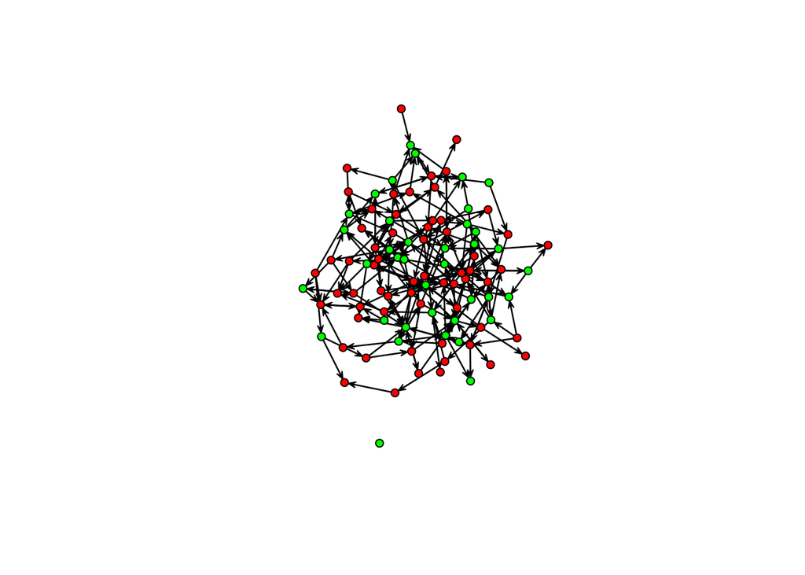

```r
Y <- ergm::simulate_formula(
  Y ~
    edges +
    nodematch("fav_music") +
    nodematch("female") +
    mutual,
  coef = c(-4, 1, -1, 2)
  )

# And visualize it!
gplot(Y, vertex.col = c("green", "red")[Y %v% "female" + 1])
```

This figure is precisely why we need ERGMs (and why many Sunbelt talks don’t include a network visualization!). We know the graph has structure (it’s not random), but visually, it is hard to see.

## 4.1 Inspect the data

For the sake of time, we will not take the time to investigate our network properly. However, you should always do so. Make sure you do descriptive statistics (density, centrality, modularity, etc.), check missing values, isolates (disconnected nodes), and inspect your data visually through “notepad” and visualizations before jumping into your ERG model.

## 4.2 Start with endogenous effects first

The step is to check whether we can fit an ERGM or not. We can do so with the Bernoulli graph:

```r
model_1 <- ergm(Y ~ edges)
summary(model_1)
```

```
Call:
ergm(formula = Y ~ edges)

Maximum Likelihood Results:

      Estimate Std. Error MCMC % z value Pr(>|z|)
edges -3.77493    0.06788      0  -55.61   <1e-04 ***
---
Signif. codes:  0 '***' 0.001 '**' 0.01 '*' 0.05 '.' 0.1 ' ' 1

     Null Deviance: 13724  on 9900  degrees of freedom
 Residual Deviance:  2125  on 9899  degrees of freedom

AIC: 2127  BIC: 2134  (Smaller is better. MC Std. Err. = 0)
```

It is rare to see a model in which the edgecount is not significant. The next term we will add is reciprocity (`mutual` in the `ergm` package)

```r
model_2 <- ergm(Y ~ edges + mutual)
## Warning: 'glpk' selected as the solver, but package 'Rglpk' is not available;
## falling back to 'lpSolveAPI'. This should be fine unless the sample size and/or
## the number of parameters is very big.
summary(model_2)
## Call:
## ergm(formula = Y ~ edges + mutual)
##
## Monte Carlo Maximum Likelihood Results:
##
##        Estimate Std. Error MCMC % z value Pr(>|z|)
## edges  -4.01430    0.07479      0  -53.68   <1e-04 ***
## mutual  2.78461    0.24231      0   11.49   <1e-04 ***
## ---
## Signif. codes:  0 '***' 0.001 '**' 0.01 '*' 0.05 '.' 0.1 ' ' 1
##
##      Null Deviance: 13724  on 9900  degrees of freedom
##  Residual Deviance:  2045  on 9898  degrees of freedom
##
## AIC: 2049  BIC: 2064  (Smaller is better. MC Std. Err. = 0.6749)
```

As expected, reciprocity is significant (we made it like this!.) Notwithstanding, there is a difference between this model and the previous one. This model was not fitted using MLE. Instead, since the reciprocity term involves more than one tie, the model cannot be reduced to a Logistic regression, so it needs to be estimated using one of the other available estimation methods in the `ergm` package.

The model starts gaining complexity as we add higher-order terms involving more ties. An infamous example is the number of triangles. Although highly important for social sciences, including triangle terms in your ERGMs results in a degenerate model (when the MCMC chain jumps between empty and fully connected graphs). One exception is if you deal with small networks. To address this, Snijders et al. (2006) and Hunter (2007) introduced various new terms that significantly reduce the risk of degeneracy. Here, we will illustrate the use of the term “geometrically weighted dyadic shared partner” (`gwdsp`,) which Prof. David Hunter proposed. The `gwdsp` term is akin to triadic closure but reduces the chances of degeneracy.

```r
# Fitting two more models (output message suppressed)
model_3 <- ergm(Y ~ edges + mutual + gwdsp(.5, fixed = TRUE))
# model_4 <- ergm(Y ~ edges + triangles) # bad idea
```

Right after fitting a model, we want to inspect the results. An excellent tool for this is the R package `texreg` (Leifeld 2013):

```r
library(texreg)
knitreg(list(model_1, model_2, model_3))
```

Statistical models

|  | Model 1 | Model 2 | Model 3 |
| --- | --- | --- | --- |
| edges | -3.77*** | -4.01*** | -3.69*** |
|  | (0.07) | (0.07) | (0.22) |
| mutual |  | 2.78*** | 2.78*** |
|  |  | (0.24) | (0.25) |
| gwdsp.OTP.fixed.0.5 |  |  | -0.08 |
|  |  |  | (0.05) |
| AIC | 2127.12 | 2049.14 | 2046.05 |
| BIC | 2134.32 | 2063.54 | 2067.65 |
| Log Likelihood | -1062.56 | -1022.57 | -1020.03 |

***p < 0.001; **p < 0.01; *p < 0.05

So far, `model_2` is winning. We will continue with this model.

## 4.3 Let’s add a little bit of structure

Now that we only have a model featuring endogenous terms, we can add vertex/edge-covariates. Starting with `"fav_music"`, there are a couple of different ways to use this node feature:

1. Directly through homophily (assortative mixing): Using the `nodematch` term, we can control for the propensity of individuals to connect based on shared music taste.
2. Homophily (v2): We could activate the option `diff = TRUE` using the same term. By doing this, the homophily term is operationalized differently, adding as many terms as options in the vertex attribute.
3. Mixing: We can use the term `nodemix` for individuals’ tendency to mix between musical tastes.

**Question**

In this context, what would be the different hypotheses behind each decision?

```r
model_4 <- ergm(Y ~ edges + mutual + nodematch("fav_music"))
model_5 <- ergm(Y ~ edges + mutual + nodematch("fav_music", diff = TRUE))
model_6 <- ergm(Y ~ edges + mutual + nodemix("fav_music"))
```

Now, let’s inspect what we have so far:

```r
knitreg(list(`2` = model_2, `4` = model_4, `5` = model_5, `6` = model_6))
```

Statistical models

|  | 2 | 4 | 5 | 6 |
| --- | --- | --- | --- | --- |
| edges | -4.01*** | -4.46*** | -4.46*** | -3.36*** |
|  | (0.07) | (0.10) | (0.11) | (0.19) |
| mutual | 2.78*** | 2.56*** | 2.54*** | 2.57*** |
|  | (0.24) | (0.27) | (0.27) | (0.26) |
| nodematch.fav_music |  | 1.00*** |  |  |
|  |  | (0.13) |  |  |
| nodematch.fav_music.jazz |  |  | 1.10*** |  |
|  |  |  | (0.21) |  |
| nodematch.fav_music.pop |  |  | 0.92*** |  |
|  |  |  | (0.17) |  |
| nodematch.fav_music.rock |  |  | 1.01*** |  |
|  |  |  | (0.15) |  |
| mix.fav_music.pop.jazz |  |  |  | -1.79*** |
|  |  |  |  | (0.46) |
| mix.fav_music.rock.jazz |  |  |  | -0.57 |
|  |  |  |  | (0.29) |
| mix.fav_music.jazz.pop |  |  |  | -0.92** |
|  |  |  |  | (0.32) |
| mix.fav_music.pop.pop |  |  |  | -0.17 |
|  |  |  |  | (0.22) |
| mix.fav_music.rock.pop |  |  |  | -1.41*** |
|  |  |  |  | (0.32) |
| mix.fav_music.jazz.rock |  |  |  | -1.29*** |
|  |  |  |  | (0.36) |
| mix.fav_music.pop.rock |  |  |  | -0.94** |
|  |  |  |  | (0.29) |
| mix.fav_music.rock.rock |  |  |  | -0.09 |
|  |  |  |  | (0.21) |
| AIC | 2049.14 | 1988.94 | 1994.09 | 1994.55 |
| BIC | 2063.54 | 2010.54 | 2030.09 | 2066.55 |
| Log Likelihood | -1022.57 | -991.47 | -992.04 | -987.27 |

***p < 0.001; **p < 0.01; *p < 0.05

```r
model_final <- ergm(Y ~ edges + mutual + nodematch("fav_music") + nodematch("female"))

# Printing the pretty table
knitreg(list(`2` = model_2, `4` = model_4, `Final` = model_final))
```

Statistical models

|  | 2 | 4 | Final |
| --- | --- | --- | --- |
| edges | -4.01*** | -4.46*** | -3.98*** |
|  | (0.07) | (0.10) | (0.12) |
| mutual | 2.78*** | 2.56*** | 2.28*** |
|  | (0.24) | (0.27) | (0.27) |
| nodematch.fav_music |  | 1.00*** | 1.00*** |
|  |  | (0.13) | (0.14) |
| nodematch.female |  |  | -1.20*** |
|  |  |  | (0.16) |
| AIC | 2049.14 | 1988.94 | 1920.54 |
| BIC | 2063.54 | 2010.54 | 1949.34 |
| Log Likelihood | -1022.57 | -991.47 | -956.27 |

***p < 0.001; **p < 0.01; *p < 0.05

## 4.4 Evaluate your results

### 4.4.1 Convergence

As our model was fitted using MCMC, we must ensure the chains converged. We can use the `mcmc.diagnostics` function from the `ergm` package to check model convergence. This function looks at the last set of simulations of the MCMC model and generates various diagnostics for the user.

Under the hood, the fitting algorithm generates a stream of networks based on those parameters for each new proposed set of model parameters. The last stream of networks is thus simulated using the final state of the model. The `mcmc.diagnostics` function takes that stream of networks and plots the sequence of the sufficient statistics included in the model. A converged model should show a stationary statistics sequence, moving around a fixed value without (a) becoming stuck at any point and (b) chaining the tendency. This model shows both:

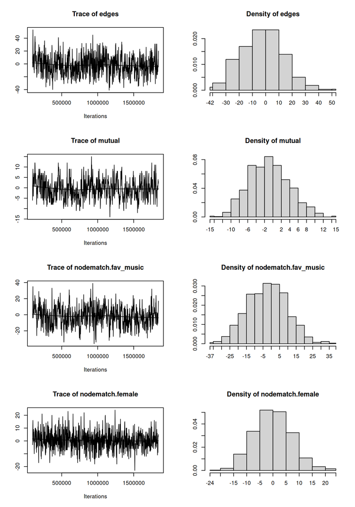

```
Note: MCMC diagnostics shown here are from the last round of
  simulation, prior to computation of final parameter estimates.
  Because the final estimates are refinements of those used for this
  simulation run, these diagnostics may understate model performance.
  To directly assess the performance of the final model on in-model
  statistics, please use the GOF command: gof(ergmFitObject,
  GOF=~model).
```

```r
mcmc.diagnostics(model_final, which   = c("plots"))
```

Now that we know our model was good enough to represent the observed statistics (sample them, actually,) let’s see how good it is at capturing other features of the network that were not included in the model.

### 4.4.2 Goodness-of-fit

This would be the last step in the sequence of steps to fit an ERGM. As we mentioned before, the idea of Goodness-of-fit [GOF] in ERG models is to see how well our model captures other properties of the graph that were not included in the model. By default, the `gof` function from the `ergm` package computes GOF for:

1. The model statistics.
2. The outdegree distribution.
3. The indegree distribution.
4. The distribution of edge-wise shared partners.
5. The distribution of the geodesic distances (shortest path).

The process of evaluating GOF is relatively straightforward. Using samples from the posterior distribution, we check whether the observed statistics from above are covered (fall within the CI) of our model. If they do, we say that the model has a good fit. Otherwise, if we observe significant anomalies, we return to the bench and try to improve our model.

As with all simulated data, our `gof()` call shows that our selected model was an excellent choice for the observed graph:

```r
gof_final <- gof(model_final)
print(gof_final)
##
## Goodness-of-fit for model statistics
##
##                     obs min   mean max MC p-value
## edges               222 194 222.57 253       0.96
## mutual               25  15  25.23  35       0.98
## nodematch.fav_music 137 114 138.03 169       1.00
## nodematch.female     50  30  49.70  63       1.00
##
## Goodness-of-fit for minimum geodesic distance
##
##      obs  min    mean  max MC p-value
## 1    222  194  222.57  253       0.96
## 2    434  343  475.03  615       0.50
## 3    750  547  877.90 1226       0.38
## 4   1106  768 1310.71 1849       0.38
## 5   1279  962 1453.11 1938       0.50
## 6   1157  778 1206.95 1641       0.80
## 7    853  334  787.69 1139       0.66
## 8    524   96  437.94  749       0.54
## 9    254   13  216.51  576       0.60
## 10   101    1  101.35  428       0.86
## 11    48    0   46.31  283       0.76
## 12    15    0   21.36  170       0.76
## 13     4    0    9.37  111       0.72
## 14     0    0    3.91   60       1.00
## 15     0    0    1.48   31       1.00
## 16     0    0    0.59   16       1.00
## 17     0    0    0.20    6       1.00
## 18     0    0    0.04    2       1.00
## Inf 3153 1248 2726.98 4719       0.52
##
## Goodness-of-fit for out-degree
##
##    obs min  mean max MC p-value
## 0   12   4 10.61  20       0.70
## 1   22  16 24.75  39       0.60
## 2   26  18 26.31  38       1.00
## 3   20  10 19.69  31       0.92
## 4   13   4 11.03  19       0.54
## 5    6   1  4.87  10       0.72
## 6    1   0  1.88   7       0.94
## 7    0   0  0.58   3       1.00
## 8    0   0  0.22   2       1.00
## 9    0   0  0.04   1       1.00
## 10   0   0  0.02   1       1.00
##
## Goodness-of-fit for in-degree
##
##   obs min  mean max MC p-value
## 0   9   4 11.03  18       0.58
## 1  27  16 24.08  36       0.52
## 2  19  17 26.70  38       0.08
## 3  31   9 19.33  33       0.02
## 4   9   5 10.93  19       0.70
## 5   3   1  5.41  14       0.46
## 6   1   0  1.66   6       1.00
## 7   1   0  0.58   4       0.88
## 8   0   0  0.21   2       1.00
## 9   0   0  0.07   1       1.00
##
## Goodness-of-fit for edgewise shared partner
##
##       obs min   mean max MC p-value
## .OTP0 213 186 212.19 243       1.00
## .OTP1   9   2  10.11  23       0.96
## .OTP2   0   0   0.27   2       1.00
```

It is easier to see the results using the `plot` function:

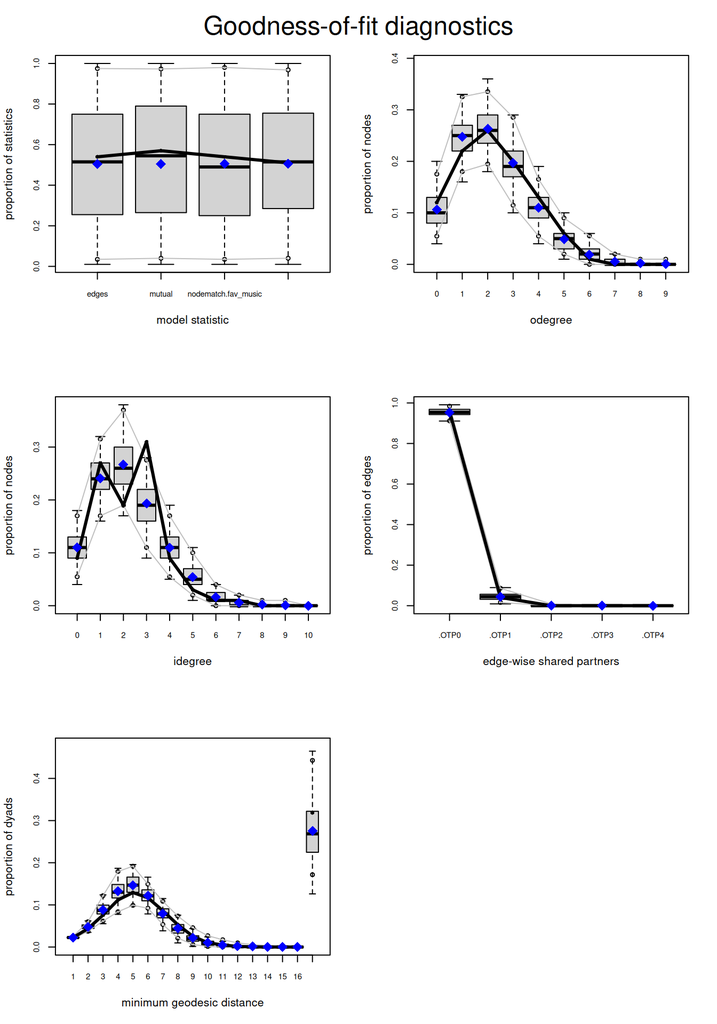

```r
# Plotting the result (5 figures)
op <- par(mfrow = c(3,2))
plot(gof_final)
par(op)
```

# 5 Conclusion

We have shown here just a glimpse of what ERG models are. A large, active, collaborative community of social network scientists is working on new extensions and advances. If you want to learn more about ERGMs, I recommend the following resources:

- The Statnet website [(link)](https://statnet.org/).
- The book “Exponential Random Graph Models for Social Networks: Theory, Methods, and Applications” by Lusher, Koskinen, and Robins (2013).
- Melnet’s PNEt website [(link)](https://www.melnet.org.au/pnet/).

# 6 Group activity

The `ergm` package comes with a handful of vignettes (extended R examples) that you can use to learn more about the package. The vignette with the same name as the package shows an example fitting a model to the network `faux.mesa.high`. Address the following questions:

1. What type of ERG model is this?
2. Looking at the plot in the vignette, what other term(s) could you consider worth adding to the model? Why?
3. The vignette did not include a goodness-of-fit analysis. Can you add one? What do you find?
4. **Challenge**: without using `ergm` to fit the model, estimate the following $p1$ model: `~ edges + nodefactor("Race")`. Compare your results with what you get using `ergm`.

## 7 References

Frank, O, and David Strauss. 1986. “Markov graphs.” *Journal of the American Statistical Association* 81 (395): 832–42. https://doi.org/10.2307/2289017.

Geyer, Charles J., and Elizabeth A. Thompson. 1992. “Constrained Monte Carlo Maximum Likelihood for Dependent Data.” *Journal of the Royal Statistical Society. Series B (Methodological)* 54 (3): 657–99. https://www.jstor.org/stable/2345852.

Holland, Paul W., and Samuel Leinhardt. 1981. “An exponential family of probability distributions for directed graphs.” *Journal of the American Statistical Association* 76 (373): 33–50. https://doi.org/10.2307/2287037.

Hunter, David R. 2007. “Curved Exponential Family Models for Social Networks.” *Social Networks* 29 (2): 216–30. https://doi.org/10.1016/j.socnet.2006.08.005.

Hunter, David R., Pavel N. Krivitsky, and Michael Schweinberger. 2012. “Computational Statistical Methods for Social Network Models.” *Journal of Computational and Graphical Statistics* 21 (4): 856–82. https://doi.org/10.1080/10618600.2012.732921.

Krivitsky, Pavel N. 2017. “Using Contrastive Divergence to Seed Monte Carlo MLE for Exponential-Family Random Graph Models.” *Computational Statistics & Data Analysis* 107 (March): 149–61. https://doi.org/10.1016/j.csda.2016.10.015.

Leifeld, Philip. 2013. “**Texreg** : Conversion of Statistical Model Output in *R* to L A T E X and HTML Tables.” *Journal of Statistical Software* 55 (8). https://doi.org/10.18637/jss.v055.i08.

Lusher, Dean, Johan Koskinen, and Garry Robins. 2013. *Exponential Random Graph Models for Social Networks: Theory, Methods, and Applications*. Cambridge University Press.

Robins, Garry, Pip Pattison, Yuval Kalish, and Dean Lusher. 2007. “An introduction to exponential random graph (p*) models for social networks.” *Social Networks* 29 (2): 173–91. https://doi.org/10.1016/j.socnet.2006.08.002.

Snijders, Tom A B, Philippa E Pattison, Garry L Robins, and Mark S Handcock. 2006. “New specifications for exponential random graph models.” *Sociological Methodology* 36 (1): 99–153. https://doi.org/10.1111/j.1467-9531.2006.00176.x.

Vega Yon, George G., Andrew Slaughter, and Kayla de la Haye. 2021. “Exponential Random Graph Models for Little Networks.” *Social Networks* 64 (August 2020): 225–38. https://doi.org/10.1016/j.socnet.2020.07.005.

Wasserman, Stanley, and Philippa Pattison. 1996. “Logit models and logistic regressions for social networks: I. An introduction to Markov graphs and p*.” *Psychometrika* 61 (3): 401–25. https://doi.org/10.1007/BF02294547.

## Footnotes

[^1]: While ERG Models can be used to predict individual ties (which is another way of describing them), the focus is on the processes that give origin to the network.
[^2]: Although later versions of the `ergm` package use the contrastive divergence by Krivitsky (2017).